# Análisis de las condiciones oceanográficas superficiales frente a Perú durante el año 1988

Analucía del Rosario Serrepe Huamaní

## 1. Introducción

Las principales variables oceanográficas tales como la temperatura superficial del mar y la salinidad, son de gran utilidad para caracterizar o determinar las condiciones instantáneas del oceáno y su relación directa con la atmósfera (Takahashi,2017), permitiendo describir y pronosticar eventos climáticos y procesos que impacten a distintos niveles de escalas espaciales y temporales. Por otro lado, es importante medir las variables relacionadas al componente biológico como clorofila que directamente refleja la productividad primaria, que está ligada a las pesquerías. El área marina frente a la costa peruana es uno de los sistema de afloramieno de borde oriental más productivos favorecido por el completo sistema de corrientes superficiales que se intensifican con lo vientos alisios (Morón,2000). De la misma forma, las condiciones climáticas se ven afectadas por los eventos ENSO que influyen directamente en las condiciones normales del mar peruano.

En ese contexto, el presente informe tiene por objetivo analizar y caracterizar la zona superficial del mar peruano en relación a la temperatura, la salinidad y la clorofila para un período específico, en este caso para el año 1988.

## 2. Materiales y metología

### 2.2 Procesamiento de las imágenes

Para obtener las imágenes, se utilizaron una serie de códigos, que se observarán en los resultados del informe para permitan reproducir las mismas grágicos.

- La temperatura superficial del mar (TSM) se analizó calculando un promedio de temperaturas de los meses correspondientes al año 1988 y luego se obtuvo un gráfico de temperatura promedio anual.
- Los gráficos de anomalías se obtuvieron haciendo una diferencia entre los valores de TSM de 1988 y el promedio de TSM de los 46 años.
- Para observar la evolución mesual de la TSM se colocaron todos las gráficos de climatologías de cada mes en un solo espacio.
- El mismo procedimiento se realizó para las variables salinidad superficial del mar y la clorofila, adicionalmente en el caso de la clorofila se calcularon los valores totales (la clorofila que representa el fitoplancton pequeño y clorofila del fitoplancton grande) para obtener gráficos de clorofila total.

## 3. Resultados y Discusiones

### 3.1 Análisis de Temperatura Superficial del Mar

La primera figura muestra la distribución espacial de la temperatura superficial del mar (TSM) en el año 1988, se puede mencionar que ese año se caracterizó por tener mayores valores de temperatura moderada que fluctúan en un rango de 20°C a 22°C en la parte central y sur de la costa peruana, y un rango de 23°C a 24°C en promedio en la parte costera del norte. Para el gráfico de anomalías de la temperatura superficial del mar se observa que no hubo una variación significativa de la temperatura, incluso en parte del sistema marino las temperaturas del mar estuvieron por debajo de sus valores normales.

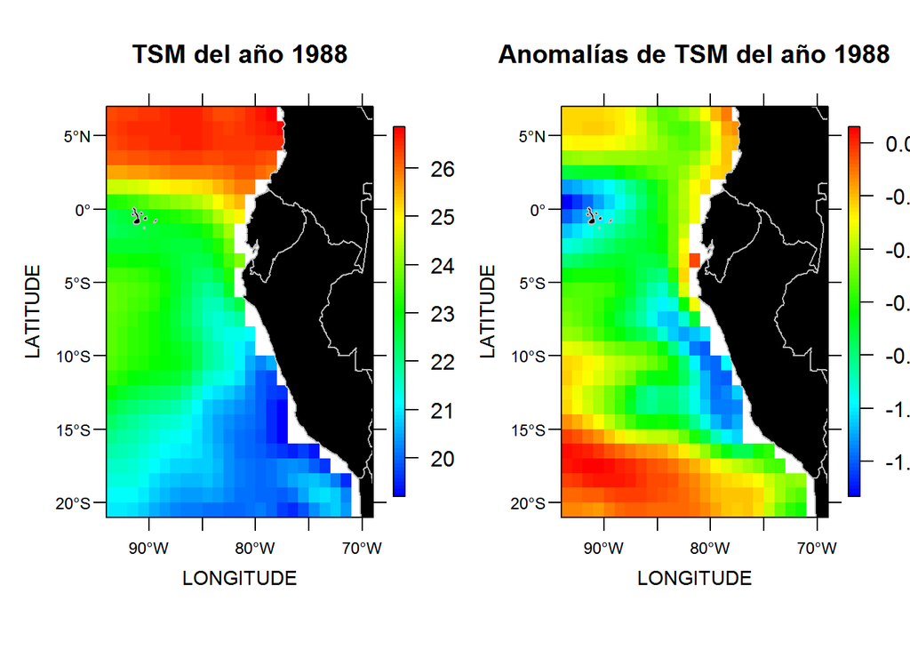

```r
#Se abre los datos de temperatura superficial del mar
Temp = nc_open("datos/sst.nc4")
TSM = ncvar_get(Temp, "to")
lat = ncvar_get(Temp, "latitude")
lon = ncvar_get(Temp, "longitude") - 360
time = ncvar_get(Temp, "time")
#Se calcula el promedio anual (1988)
TSM_mean = apply(TSM[,,349:360], MARGIN = c(1,2), FUN = mean, na.rm = TRUE)
#Para hallar la anomalía anual
TSM_allyears = apply(TSM[,,1:552], MARGIN = c(1,2), FUN = mean, na.rm = TRUE)
ATSM1988 = TSM_mean - TSM_allyears
par(mfrow=c(1,2))
image.map(lon, lat, TSM_mean, main="TSM del año 1988")
image.map(lon, lat, ATSM1988, main="Anomalías de TSM del año 1988")
```

#### Anomalías de la Temperatura Superficial del Mar de Enero (mes cálido) y de Agosto (mes frío)

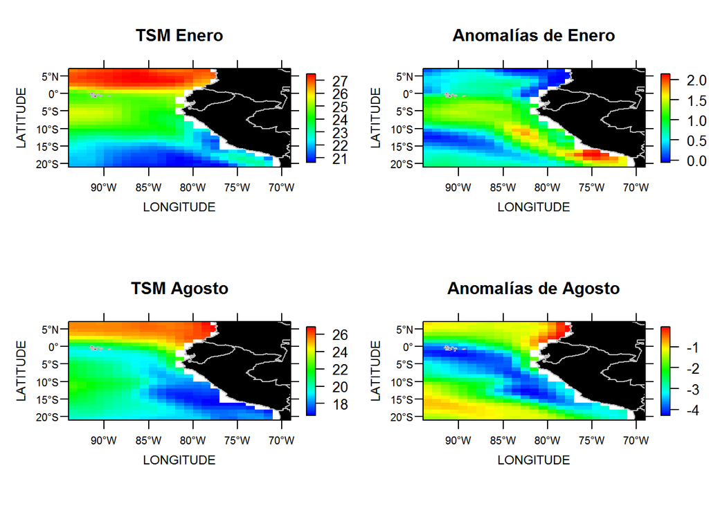

```r
#Hallando las anomalías para Enero y Agosto
ATSM_enero = TSM[,,349] - TSM_allyears
TSM_enero = TSM[,,349]
ATSM_agosto = TSM[,,356] - TSM_allyears
TSM_agosto = TSM[,,356]
#Graficando
par(mfrow=c(2,2))
image.map(lon, lat, TSM_enero, main="TSM Enero")
image.map(lon, lat, ATSM_enero, main="Anomalías de Enero")
image.map(lon, lat, TSM_agosto, main="TSM Agosto")
image.map(lon, lat, ATSM_agosto, main="Anomalías de Agosto")
```

#### Evolución de la Temperatura Superficial del Mar para todos los meses

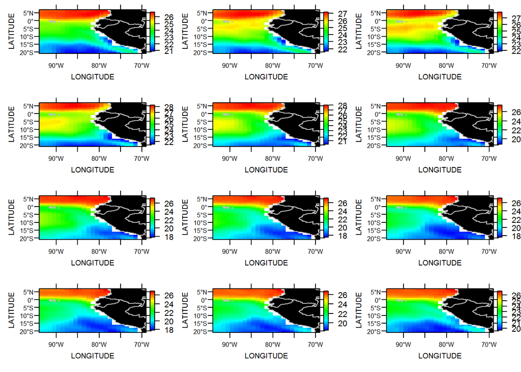

```r
#Para las climatologías se realizaron los siguientes códigos
Temp = nc_open("datos/sst.nc4")
TSM = ncvar_get(Temp, "to")
lat = ncvar_get(Temp, "latitude")
lon = ncvar_get(Temp, "longitude") - 360
time = ncvar_get(Temp, "time")

year1988=time[349:360]
meses=rep(1:12,length=length(year1988))

for(i in 1:12){
  apply(TSM[,,meses==1],MARGIN=c(1,2),
        FUN=mean,na.rm=TRUE)}

clim=array(dim=c(dim(TSM)[1:2],12))

for(i in 1:12){
  clim[,,i]=apply(TSM[,,meses==i],MARGIN=c(1,2),
                  FUN=mean,na.rm=TRUE)
}
par(mfrow=c(4,3),mar=c(4,4,1,1))
for(i in 1:12)
  image.map(lon,lat,clim[,,i])
```

### 3.2 Análisis de la Salinidad Superficial del Mar

#### Salinidad Superficial del Mar del año 1988

En relación a la salinidad superficial del mar, el año 1988 se caracterizó por presentar valores de salinidad de 35 psu en promedio anual.

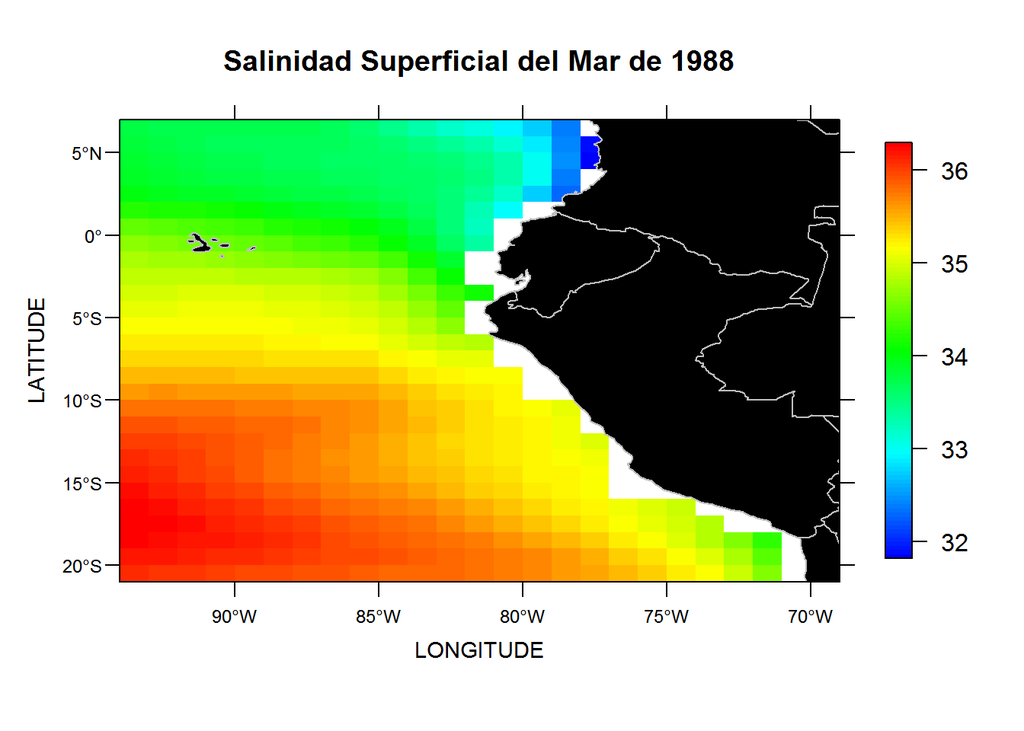

```r
#Se abre los datos de la salinidad superficial del mal
Sali = nc_open("datos/sss.nc4")
SSM = ncvar_get(Sali, "so")
lat = ncvar_get(Sali, "latitude")
lon = ncvar_get(Sali, "longitude") - 360
time = ncvar_get(Sali, "time")
#Se calcula el promedio anual (1988) y se grafica
sali_mean = apply(SSM[,,349:360], MARGIN = c(1,2), FUN = mean, na.rm = TRUE)
image.map(lon, lat, sali_mean, main="Salinidad Superficial del Mar de 1988")
```

Las climatologías de la salinidad superficial del mar (SSM) indican que los valores fluctuan entre los valores de 35 psu, La evolución mensual de la salinidad indica que hay una variación reducidad de los valores de este parámetro, sin embargo espacialmente se observa que hay zonas de baja salinidad asociada a los aportes de los ríos costeros y también por las aguas de las corrientes ecuaroriales traen aguas con baja salinidad producto de las altas precipitaciones del pacífico ecuatorial.

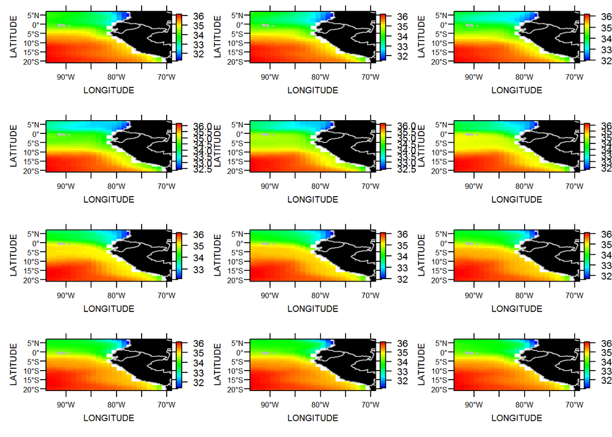

```r
#Para las climatologías se realizaron los siguientes códigos
Sali = nc_open("datos/sss.nc4")
SSM = ncvar_get(Sali, "so")
lat = ncvar_get(Sali, "latitude")
lon = ncvar_get(Sali, "longitude") - 360
time = ncvar_get(Sali, "time")

year1988=time[349:360]
meses=rep(1:12,length=length(year1988))

for(i in 1:12){
  apply(SSM[,,meses==1],MARGIN=c(1,2),
        FUN=mean,na.rm=TRUE)}

clim=array(dim=c(dim(SSM)[1:2],12))

for(i in 1:12){
  clim[,,i]=apply(SSM[,,meses==i],MARGIN=c(1,2),
                  FUN=mean,na.rm=TRUE)
}

par(mfrow=c(4,3),mar=c(4,4,1,1))
for(i in 1:12)
  image.map(lon,lat,clim[,,i])
```

### 3.3 Análisis espacial y temporal de la Clorofila Total

#### Gráfica de la Clorofila del Fitoplancton Pequeño y Grande

Se observa que los altos valores de la clorofila del fitoplancton grande y el fitoplancton pequeño se distribuyen espacialmente en zonas distintas de la costa marina.

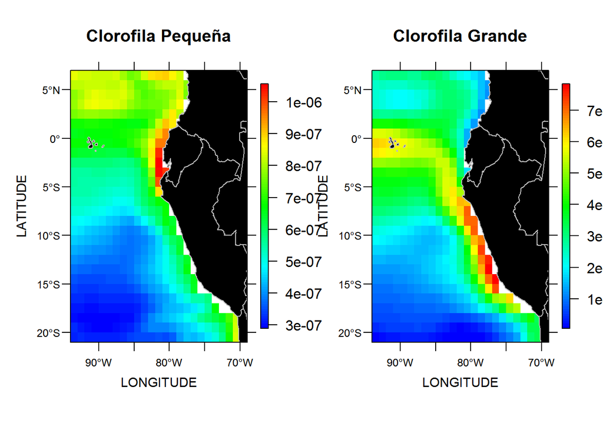

```r
#Clorofila del fitoplancton pequeño
sphy = nc_open("datos/sphy.nc4")
sclorofila = ncvar_get(sphy, "intpp")
lat = ncvar_get(sphy, "latitude")
lon = ncvar_get(sphy, "longitude") - 360
scloro_mean = apply(sclorofila[,,349:360], MARGIN = c(1,2), FUN = mean, na.rm = TRUE)

#Clorofila del fitoplancton grande
lphy = nc_open("datos/lphy.nc4")
lclorofila = ncvar_get(lphy, "intpp")
lat = ncvar_get(lphy, "latitude")
lon = ncvar_get(lphy, "longitude") - 360
lcloro_mean = apply(lclorofila[,,349:360], MARGIN = c(1,2), FUN = mean, na.rm = TRUE)

#Graficando las dos clorofilas
par(mfrow=c(1,2))
image.map(lon, lat, scloro_mean, main="Clorofila Pequeña")
image.map(lon, lat, lcloro_mean, main="Clorofila Grande")
```

#### Gráfica de la Clorofila Total

Se sumaron ambos valores de clorofila del fitoplancton pequeño y grande para tener un gráfico de la clorofila total promedi del año 1988. Este parámetro indica por lo tanto la alta productividad del sistema de afloramiento peruano, debido a la surgencia que advecta los nutrientes a la zona fótica superficial.

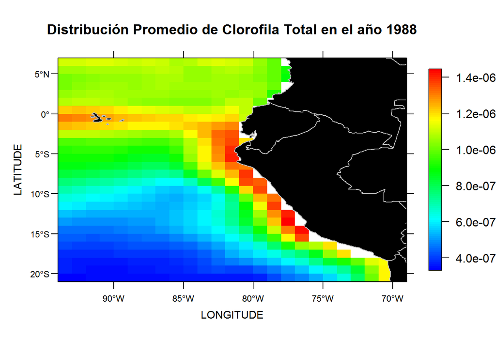

```r
#Hallando la clorofila total
clorofila_total= scloro_mean + lcloro_mean
image.map(lon, lat, clorofila_total, main="Distribución Promedio de Clorofila Total en el año 1988")
```

Los mayores valores de clorofila total se dan en verano porque la productividad llega a su máxima en meses cálidos. Los siguientes meses serán fase de calma y luego una paulatina disminución de la productiva y con ello se verán beneficiados ciertos organismos fitoplanctónicos.

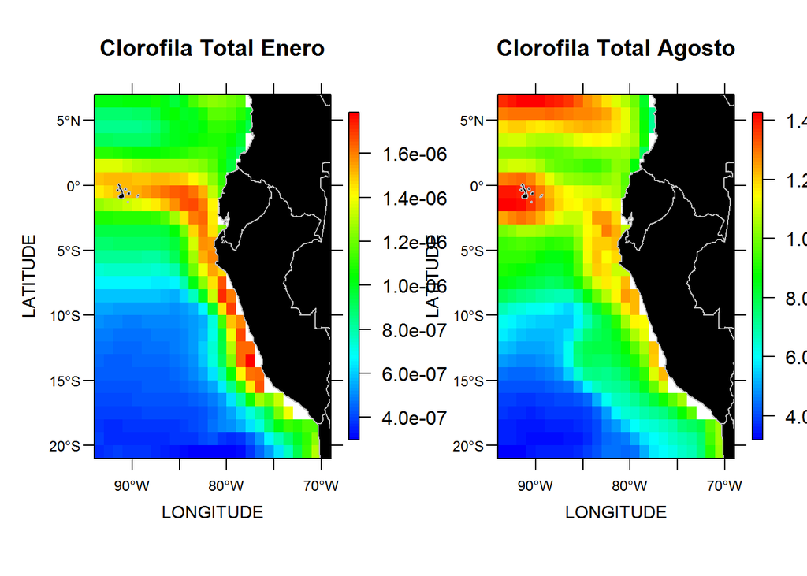

```r
#Hallando las clorofila total para Enero y Agosto
sphy = nc_open("datos/sphy.nc4")
sclorofila = ncvar_get(sphy, "intpp")
lat = ncvar_get(sphy, "latitude")
lon = ncvar_get(sphy, "longitude") - 360
scloro_enero = sclorofila[,,349]
scloro_agosto = sclorofila[,,356]

lphy = nc_open("datos/lphy.nc4")
lclorofila = ncvar_get(lphy, "intpp")
lat = ncvar_get(lphy, "latitude")
lon = ncvar_get(lphy, "longitude") - 360
lcloro_enero = lclorofila[,,349]
lcloro_agosto = lclorofila[,,356]

clorofila_total_enero= scloro_enero + lcloro_enero
clorofila_total_agosto= scloro_agosto + lcloro_agosto

#Graficando
par(mfrow=c(1,2))
image.map(lon, lat, clorofila_total_enero, main="Clorofila Total Enero")
image.map(lon, lat, clorofila_total_agosto, main="Clorofila Total Agosto")
```

## 5. Referencias

Takahashi, K. 2017. Estimación de la distribución de la temperatura superficial del mar. Boletín Técnico “Generación de modelos climáticos para el pronóstico de la ocurrencia del Fenómeno El Niño”. Instituto Geofísico del Perú. Pag 8-10. [Archivo PDF](http://www.met.igp.gob.pe/publicaciones/Divulgacion_PPR_El_Nino_IGP_201702.pdf)

Quispe, D., Graco, M., Correa, D., Tam, J., Gutiérrez, D., Morón, O., Flores, G. & Yamashiro, C. (2010). Variabilidad espacio-temporal de condiciones hidrofísicas en Bahía Independencia, Pisco – Perú. Ecología Aplicada 9 (1):9-18. [Archivo PDF](http://www.imarpe.pe/imarpe/imagenes/portal/imarpe/ecap-9-9-quispe-2010-rnp.pdf)

Santander, E., Herrera, L., & Merino, C. (2003). Fluctuación diaria del fitoplancton en la capa superficial del océano durante la primavera de 1997 en el norte de Chile (20°18´S): II. Composición específica y abundancia celular. Revista de biología marina y oceanografía, 38(1), 13-25. [Archivo PDF](http://www.scielo.cl/pdf/revbiolmar/v38n1/art02.pdf)

Morón, O. (2000). Características del ambiente marino frente a la costa peruana. Boletin del Instituto del Mar del Perú 19, 179–204. [Archivo PDF](http://www.imarpe.gob.pe/paita/publicaciones/caract_del_amb_marino.pdf)

Quezada, M., Paredes, R., Carrillo, F., & Rojas, J. (2014). Variabilidad espacial y temporal de la concentración de clorofila-a en el mar peruano usando imágenes MODIS-AQUA. Revista De Investigación de Física, 14(02). [Archivo PDF](http://ateneo.unmsm.edu.pe/ateneo/bitstream/123456789/2791/1/revista_de_investigacion_de_fisica06v14n2_2011.pdf)